# What’s the Trump’s Tweets Association?

## Unsupervised Learning Primier: Association Rule Mining

## Abstract

This article“s goal is to explore the possibilities of unsupervised learning methods in Data Science. I am currently enrolled in the 1st semester of CEE”s Best Data Science Programme, MSc in Data Science at the University of Warsaw. By this time, I can tell, that association rule mining is fundamental to acquire if you wish to have a successful career in Data Science or Machine Learning.

These methods are often connected to transaction analytics. We look for the relations between items. It works similar to correlation, but the items we purchase are categorical values, not integers or floats, that is why we use association rules, which you can think of like the correlation between sets. But, the universe of use cases we can apply this method is far broader than our grocery baskets. We can use it for images, or sentences. We can treat sentences like baskets or transactions with multiple items inside. An author decides upon which words to use, just like we decide what to put to our grocery basket.

Here, I will use Twitter Data, regarding [Donald Trump“s Tweets](https://www.kaggle.com/kingburrito666/better-donald-trump-tweets), which can be found on Kaggle Datasets. I will explore the association between words and sentiment inside the short texts. Twitter helps here a lot because Tweets have a character limit and often consists of several words, to transport the message.

Happy Reading!

## Exploratory Data Analysis

```r
data = read.csv2("Donald-Tweets!.csv", header = T, sep = ",")
str(data)
```

```
## 'data.frame':    7375 obs. of  12 variables:
##  $ Date                                     : Factor w/ 479 levels "15-07-16","15-07-17",..: 479 479 479 479 479 478 477 477 477 476 ...
##  $ Time                                     : Factor w/ 7015 levels "0:00:08","0:00:38",..: 2590 1911 1073 4330 4239 3985 1182 4568 660 5870 ...
##  $ Tweet_Text                               : Factor w/ 7364 levels ". #JoeTheismann was great as a political analyst on @FoxNews. He knows far more than football. Thanks for the nice words Joe!",..: 6738 2963 4751 4578 2717 3519 5820 6916 5506 5432 ...
##  $ Type                                     : Factor w/ 3 levels "link","text",..: 2 2 2 2 2 2 2 2 2 2 ...
##  $ Media_Type                               : Factor w/ 2 levels "","photo": 2 1 1 1 1 2 1 2 1 1 ...
##  $ Hashtags                                 : Factor w/ 792 levels "","12HR;AMERICAN;WE",..: 560 1 1 1 1 1 1 183 1 378 ...
##  $ Tweet_Id                                 : Factor w/ 177 levels "6.21E+17","6.22E+17",..: 177 177 177 177 177 177 176 176 176 176 ...
##  $ Tweet_Url                                : Factor w/ 7375 levels "https://twitter.com/realDonaldTrump/status/621474680944373761",..: 7375 7374 7373 7372 7371 7370 7369 7368 7367 7366 ...
##  $ twt_favourites_IS_THIS_LIKE_QUESTION_MARK: int  127213 141527 183729 214001 178499 159176 627615 185160 99809 63868 ...
##  $ Retweets                                 : int  41112 28654 50039 67010 36688 44655 225164 45492 17169 19710 ...
##  $ X                                        : num  NA NA NA NA NA NA NA NA NA NA ...
##  $ X.1                                      : Factor w/ 5 levels "","6.38E+17",..: 1 1 1 1 1 1 1 1 1 1 ...
```

- Date: Datestamp of each Tweet in YY-MM-DD format,
- Time: Timestamp of each Tweet in HH-MM-SS format,
- Tweet_Text: The actual text content of each Tweet,
- Type: an indication, whether the Tweet was pure text, or text related to the link (“text”/“link”),
- Media_Type: an indication, whether the Tweet was pure text, or text related to the photo (“null”/“photo”),
- Hashtags: any written hashtags in the Tweet,
- Tweet_Id: unique value for each Tweet,
- Tweet_Url: unique link to each Tweet,
- twt_favourites_IS_THIS_LIKE_QUESTION_MARK: number of favourites, that are assigned to certain Tweet,
- Retweets: number of retweets, that are assigned to certain Tweet,
- X and X.1 columns that do not have documentation.

For the purpose of this research project, I will use only a part of accessible columns and characteristics of each Tweet. Moreover, I will make use only of a portion of the Tweets. I would like to get rid of any Tweets with external context, meaning those with Hashtags, Links and Photos will be dropped, as they may refer directly to different source or event.

```r
data = filter(data, Type == "text",
              Media_Type == "",
              Hashtags == "")

dataText = as.data.frame(data[,c("Tweet_Text")])
colnames(dataText) = c("Tweet")

sample_n(as.tbl(dataText), 10)
```

```
## # A tibble: 10 x 1
##    Tweet
##    <fct>
##  1 "Wonder if Obama will ever say RADICAL ISLAMIC TERRORIST?"
##  2 "Thank you to the Governor of Florida, Rick Scott, for your endorsement…
##  3 "RT @AnnCoulter: GREATEST FOREIGN POLICY SPEECH SINCE WASHINGTONS FAREW…
##  4 "\"@JoeNBC: @jonkarl: \"This has been a great debate for Donald Trump.\…
##  5 "From day one I said that I was going to build a great wall on the SOUT…
##  6 "\"@TrumpFix: @meganena13 @robertew2945 agreed Luisa. @realDonaldTrump …
##  7 "\"@TheBrodyFile: On the Muslim issue: It might help @BarackObama if he…
##  8 "\"@BornToBeGOP: @realDonaldTrump you are always many steps ahead of th…
##  9 "Obama has blocked ICE officers and BP from doing their jobs. That ends…
## 10 "\"@seleti00: @realDonaldTrump @FoxNews They attack you more then CNN o…
```

Now, we need to firsly, get rid of the misleading characters like `\n`, which was typed in text to indicate hard enter, and extract individual words from the Tweets. Also, we will make sure, that stopwords are deleted (however, I am living stopwords like “we”, given that these are Tweets from the middle of a Presidential Campaing, and this can matter in the analysis). (Un)fortunately, we ended up with a list of lists, that need to be unpacked and rewritten into the matrix.

```r
sample(stopwords, 5)
```

```
## [1] "can"   "few"   "on"    "yours" "how"
```

```r
cleanLink = function(x) gsub("\n", " ", x)
cleanStopwords = function(x) gsub(stopwords, "", x)
stringSep = function(x) str_split(x, " ")

dataText = dataText %>%
  apply(2, cleanLink)

dataText = dataText %>%
  apply(2, cleanStopwords)
dataSeparated = apply(dataText, 2, stringSep)

dataBasket = matrix(nrow = lengths(dataSeparated[1]),
                    ncol = max(lengths(dataSeparated[[1]]))
                    )

for(i in 1:lengths(dataSeparated)){
  for(j in 1:lengths(dataSeparated[[1]][i])){
    dataBasket[i,j] = dataSeparated[[1]][[i]][j]
  }
}

dataBasketSmall = dataBasket[1:250,]

write.csv2(dataBasketSmall, "dataBasketSmall.csv")
```

After a quick clean of artificial columnNames, Index value, as well as deleting links, “@Username” values and punctuation marks, we can load our “Transaction Data”. It could have beed done in R, by replacing values, that meet certain requirements, but Excel was faster and I could review the data once more. And the data processing part is not the core of this analysis. One can write many Primiers on dealing with strings, webscraping text datasets and applying regular expressions to clearing.

During the creation of this project I encountered a certain pecularity, which is connected to analyzing natural language using association rules (or market basket analysis).

Tweets are substantially more heterogeneuous that baskets of products. When at first, I ran the algorithms without deleting the stopwords, the rules were working great, but the analysis lost its sense, as most of the rules were just the English stopwords like “in”, “at”, “the”, etc.

When I decided, to remove stopwords, the sample of N Tweets, was too heterogeneous to create any relevant rules. In other words, when we extract only the nouns and verbs, without stopwords, Tweets are becoming too different from each other.

Below is the example of very short, homogeneous subset of tweets, and in parallel I show the analysis of the bigger subset, but with stopwords included

## Introduction

```r
Tweets_1 = read.transactions("dataBasketSmallCleaned_Short.csv", rm.duplicates = F, format = "basket", sep = ";", skip = 0)

Tweets_2 = read.transactions("dataBasketSmall_withStopwords.csv", rm.duplicates = F, format = "basket", sep = ";", skip = 0)

Tweets_1
```

```
## transactions in sparse format with
##  20 transactions (rows) and
##  198 items (columns)
```

```r
Tweets_2
```

```
## transactions in sparse format with
##  100 transactions (rows) and
##  740 items (columns)
```

```r
# Showing "Busy day planned in New York Will soon be making some very important decisions on the people who will be running our government"
LIST(head(Tweets_1, 1))
```

```
## [[1]]
##  [1] "Busy"       "day"        "decisions"  "government" "important"
##  [6] "making"     "New"        "our"        "people"     "planned"
## [11] "running"    "some"       "soon"       "very"       "who"
## [16] "York"
```

```r
LIST(head(Tweets_2, 1))
```

```
## [[1]]
##  [1] "be"         "Busy"       "day"        "decisions"  "government"
##  [6] "important"  "in"         "making"     "New"        "on"
## [11] "our"        "people"     "planned"    "running"    "some"
## [16] "soon"       "the"        "very"       "who"        "will"
## [21] "Will"       "York"
```

```r
itemFrequency(Tweets_2)["Hillary"]
```

```
## Hillary
##    0.15
```

```r
itemFrequency(Tweets_2)["US"]
```

```
##   US
## 0.03
```

We can see, that from the sample of 100 Tweets with stopwords, 15% was connected to the word “Hillary”, and 3.0% to the word “US”. Because of the number of items (words) in sample, I will show only the most interesting partion of measure matrices below.

```r
crossTable(Tweets_2, measure = "count", sort = T)[1:10,1:10]
```

```
##      in to the and you be for of  a will
## in   40 11  12   8   7  8   6  5  5    4
## to   11 35  12  11  12  8   6  7  8    4
## the  12 12  31  12   8  6   7 11  3    7
## and   8 11  12  26   9  8   6 11  8    6
## you   7 12   8   9  23  0   5  5  1    3
## be    8  8   6   8   0 20   3  2  6    9
## for   6  6   7   6   5  3  19  6  7    4
## of    5  7  11  11   5  2   6 18  5    3
## a     5  8   3   8   1  6   7  5 17    4
## will  4  4   7   6   3  9   4  3  4   17
```

```r
crossTable(Tweets_2, measure = "probability", sort = T)[1:10,1:10]
```

```
##        in   to  the  and  you   be  for   of    a will
## in   0.40 0.11 0.12 0.08 0.07 0.08 0.06 0.05 0.05 0.04
## to   0.11 0.35 0.12 0.11 0.12 0.08 0.06 0.07 0.08 0.04
## the  0.12 0.12 0.31 0.12 0.08 0.06 0.07 0.11 0.03 0.07
## and  0.08 0.11 0.12 0.26 0.09 0.08 0.06 0.11 0.08 0.06
## you  0.07 0.12 0.08 0.09 0.23 0.00 0.05 0.05 0.01 0.03
## be   0.08 0.08 0.06 0.08 0.00 0.20 0.03 0.02 0.06 0.09
## for  0.06 0.06 0.07 0.06 0.05 0.03 0.19 0.06 0.07 0.04
## of   0.05 0.07 0.11 0.11 0.05 0.02 0.06 0.18 0.05 0.03
## a    0.05 0.08 0.03 0.08 0.01 0.06 0.07 0.05 0.17 0.04
## will 0.04 0.04 0.07 0.06 0.03 0.09 0.04 0.03 0.04 0.17
```

```r
crossTable(Tweets_2, measure = "lift", sort = T)[1:5,1:5]
```

```
##            in        to       the       and       you
## in         NA 0.7857143 0.9677419 0.7692308 0.7608696
## to  0.7857143        NA 1.1059908 1.2087912 1.4906832
## the 0.9677419 1.1059908        NA 1.4888337 1.1220196
## and 0.7692308 1.2087912 1.4888337        NA 1.5050167
## you 0.7608696 1.4906832 1.1220196 1.5050167        NA
```

## Key Measures

Before moving into the next parts of the analysis, let me introduce our key measures, that are the core of the Association Rule Mining. As you can see, I am not explaining it in generic manner, but adjusted to our dataset. I am sure you can find a lot of documentation on the web as well.

- Support: Ratio between (Number of Tweets with word X and word Y) and (Total number of Tweets)
- Confidence: Ratio between (Number of Tweets with word X and word Y) and (Total number of Tweets with word X)
- Expected Confidence: Ratio between (Number of Tweets with word Y) and (Total number of Tweets)
- Lift: Ratio between Confidence and Expected Confidence

Now, I will create rules. They explain occurence of certain variables with different one in Tweets (transactions). As I have a lot of words (items) in Tweets (transactions), I will set the support measurement to the 15% for the smaller subset and 10% for the bigger (with stopwords included), which will filter the data more. I am also setting the maximum lenght, in order to prevent the algorithm from creating too long rules.

```r
frequencyTweets_1 = eclat(Tweets_1, parameter = list(supp = .15, maxlen = 15))
```

```
## Eclat
##
## parameter specification:
##  tidLists support minlen maxlen            target   ext
##     FALSE    0.15      1     15 frequent itemsets FALSE
##
## algorithmic control:
##  sparse sort verbose
##       7   -2    TRUE
##
## Absolute minimum support count: 3
##
## create itemset ...
## set transactions ...[198 item(s), 20 transaction(s)] done [0.00s].
## sorting and recoding items ... [8 item(s)] done [0.00s].
## creating bit matrix ... [8 row(s), 20 column(s)] done [0.00s].
## writing  ... [9 set(s)] done [0.00s].
## Creating S4 object  ... done [0.00s].
```

```r
inspect(frequencyTweets_1)
```

```
##     items           support count
## [1] {Hampshire,New} 0.15    3
## [2] {We}            0.20    4
## [3] {great}         0.20    4
## [4] {New}           0.20    4
## [5] {election}      0.15    3
## [6] {vote}          0.15    3
## [7] {with}          0.15    3
## [8] {Hampshire}     0.15    3
## [9] {Michigan}      0.15    3
```

```r
frequencyRulesSmall = ruleInduction(frequencyTweets_1, Tweets_1, confidence = .15)
inspect(frequencyRulesSmall)
```

```
##     lhs            rhs         support confidence lift itemset
## [1] {New}       => {Hampshire} 0.15    0.75       5    1
## [2] {Hampshire} => {New}       0.15    1.00       5    1
```

Above, you can see rules, that meet the requirements of minimal confidence of 15%. Those are groups of words, that together occured in more than 15% of Tweets, that the lhs word occured.

```r
frequencyTweets_2 = eclat(Tweets_2, parameter = list(supp = .10, maxlen = 15))
```

```
## Eclat
##
## parameter specification:
##  tidLists support minlen maxlen            target   ext
##     FALSE     0.1      1     15 frequent itemsets FALSE
##
## algorithmic control:
##  sparse sort verbose
##       7   -2    TRUE
##
## Absolute minimum support count: 10
##
## create itemset ...
## set transactions ...[740 item(s), 100 transaction(s)] done [0.00s].
## sorting and recoding items ... [22 item(s)] done [0.00s].
## creating bit matrix ... [22 row(s), 100 column(s)] done [0.00s].
## writing  ... [34 set(s)] done [0.00s].
## Creating S4 object  ... done [0.00s].
```

```r
inspect(frequencyTweets_2)
```

```
##      items        support count
## [1]  {in,Join}    0.10    10
## [2]  {in,me}      0.12    12
## [3]  {Thank,you}  0.13    13
## [4]  {Hillary,to} 0.10    10
## [5]  {of,the}     0.11    11
## [6]  {and,of}     0.11    11
## [7]  {to,you}     0.12    12
## [8]  {and,to}     0.11    11
## [9]  {and,the}    0.12    12
## [10] {the,to}     0.12    12
## [11] {in,the}     0.12    12
## [12] {in,to}      0.11    11
## [13] {to}         0.35    35
## [14] {in}         0.40    40
```

[output cut: 20 more lines]

```r
frequencyRulesStopwords = ruleInduction(frequencyTweets_2, Tweets_2, confidence = .50)
inspect(frequencyRulesStopwords)
```

```
##     lhs          rhs     support confidence lift     itemset
## [1] {Join}    => {in}    0.10    1.0000000  2.500000 1
## [2] {me}      => {in}    0.12    0.8571429  2.142857 2
## [3] {you}     => {Thank} 0.13    0.5652174  4.347826 3
## [4] {Thank}   => {you}   0.13    1.0000000  4.347826 3
## [5] {Hillary} => {to}    0.10    0.6666667  1.904762 4
## [6] {of}      => {the}   0.11    0.6111111  1.971326 5
## [7] {of}      => {and}   0.11    0.6111111  2.350427 6
## [8] {you}     => {to}    0.12    0.5217391  1.490683 7
```

Above, you can see rules, that meet the requirements of minimal confidence of 50%. Those are groups of words, that together occured in more than 50% of Tweets, that the lhs word occured. Now we might inspect the data further using apriori() function.

```r
aprioriTweets_1 = apriori(Tweets_1, parameter = list(supp = .1, confidence = .05))
```

```
## Apriori
##
## Parameter specification:
##  confidence minval smax arem  aval originalSupport maxtime support minlen
##        0.05    0.1    1 none FALSE            TRUE       5     0.1      1
##  maxlen target   ext
##      10  rules FALSE
##
## Algorithmic control:
##  filter tree heap memopt load sort verbose
##     0.1 TRUE TRUE  FALSE TRUE    2    TRUE
##
## Absolute minimum support count: 2
##
## set item appearances ...[0 item(s)] done [0.00s].
## set transactions ...[198 item(s), 20 transaction(s)] done [0.00s].
## sorting and recoding items ... [41 item(s)] done [0.00s].
## creating transaction tree ... done [0.00s].
## checking subsets of size 1 2 3 4 5 6 done [0.00s].
## writing ... [290 rule(s)] done [0.00s].
## creating S4 object  ... done [0.00s].
```

```r
inspect(head((sort(aprioriTweets_1, by = "support", decreasing = T))))
```

```
##     lhs    rhs         support confidence lift count
## [1] {}  => {New}       0.20    0.20       1    4
## [2] {}  => {great}     0.20    0.20       1    4
## [3] {}  => {We}        0.20    0.20       1    4
## [4] {}  => {Michigan}  0.15    0.15       1    3
## [5] {}  => {Hampshire} 0.15    0.15       1    3
## [6] {}  => {with}      0.15    0.15       1    3
```

```r
inspect(head((sort(aprioriTweets_1, by = "confidence", decreasing = T))))
```

```
##     lhs               rhs        support confidence lift      count
## [1] {Pennsylvania} => {Michigan} 0.1     1           6.666667 2
## [2] {AMERICA}      => {GREAT}    0.1     1          10.000000 2
## [3] {GREAT}        => {AMERICA}  0.1     1          10.000000 2
## [4] {AMERICA}      => {MAKE}     0.1     1          10.000000 2
## [5] {MAKE}         => {AMERICA}  0.1     1          10.000000 2
## [6] {GREAT}        => {MAKE}     0.1     1          10.000000 2
```

```r
inspect(head((sort(aprioriTweets_1, by = "lift", decreasing = T))))
```

```
##     lhs          rhs       support confidence lift count
## [1] {AMERICA} => {GREAT}   0.1     1          10   2
## [2] {GREAT}   => {AMERICA} 0.1     1          10   2
## [3] {AMERICA} => {MAKE}    0.1     1          10   2
## [4] {MAKE}    => {AMERICA} 0.1     1          10   2
## [5] {GREAT}   => {MAKE}    0.1     1          10   2
## [6] {MAKE}    => {GREAT}   0.1     1          10   2
```

```r
aprioriTweets_2 = apriori(Tweets_2, parameter = list(supp = .1, confidence = .05))
```

```
## Apriori
##
## Parameter specification:
##  confidence minval smax arem  aval originalSupport maxtime support minlen
##        0.05    0.1    1 none FALSE            TRUE       5     0.1      1
##  maxlen target   ext
##      10  rules FALSE
##
## Algorithmic control:
##  filter tree heap memopt load sort verbose
##     0.1 TRUE TRUE  FALSE TRUE    2    TRUE
##
## Absolute minimum support count: 10
##
## set item appearances ...[0 item(s)] done [0.00s].
## set transactions ...[740 item(s), 100 transaction(s)] done [0.00s].
## sorting and recoding items ... [22 item(s)] done [0.00s].
## creating transaction tree ... done [0.00s].
## checking subsets of size 1 2 3 done [0.00s].
## writing ... [46 rule(s)] done [0.00s].
## creating S4 object  ... done [0.00s].
```

```r
inspect(head((sort(aprioriTweets_2, by = "support", decreasing = T))))
```

```
##     lhs    rhs   support confidence lift count
## [1] {}  => {in}  0.40    0.40       1    40
## [2] {}  => {to}  0.35    0.35       1    35
## [3] {}  => {the} 0.31    0.31       1    31
## [4] {}  => {and} 0.26    0.26       1    26
## [5] {}  => {you} 0.23    0.23       1    23
## [6] {}  => {be}  0.20    0.20       1    20
```

```r
inspect(head((sort(aprioriTweets_2, by = "confidence", decreasing = T))))
```

```
##     lhs          rhs   support confidence lift     count
## [1] {Join}    => {in}  0.10    1.0000000  2.500000 10
## [2] {Thank}   => {you} 0.13    1.0000000  4.347826 13
## [3] {me}      => {in}  0.12    0.8571429  2.142857 12
## [4] {Hillary} => {to}  0.10    0.6666667  1.904762 10
## [5] {of}      => {and} 0.11    0.6111111  2.350427 11
## [6] {of}      => {the} 0.11    0.6111111  1.971326 11
```

```r
inspect(head((sort(aprioriTweets_2, by = "lift", decreasing = T))))
```

```
##     lhs        rhs     support confidence lift     count
## [1] {Thank} => {you}   0.13    1.0000000  4.347826 13
## [2] {you}   => {Thank} 0.13    0.5652174  4.347826 13
## [3] {Join}  => {in}    0.10    1.0000000  2.500000 10
## [4] {in}    => {Join}  0.10    0.2500000  2.500000 10
## [5] {of}    => {and}   0.11    0.6111111  2.350427 11
## [6] {and}   => {of}    0.11    0.4230769  2.350427 11
```

```r
tweetsHillary = apriori(Tweets_2, parameter = list(supp = .01, confidence = .01),
                       appearance = list(default = "lhs", rhs = "Hillary"), control = list(verbose = F))

inspect(head((sort(tweetsHillary, by = "support", decreasing = T))))
```

```
##     lhs          rhs       support confidence lift     count
## [1] {}        => {Hillary} 0.15    0.1500000  1.000000 15
## [2] {to}      => {Hillary} 0.10    0.2857143  1.904762 10
## [3] {Crooked} => {Hillary} 0.07    0.8750000  5.833333  7
## [4] {a}       => {Hillary} 0.06    0.3529412  2.352941  6
## [5] {the}     => {Hillary} 0.05    0.1612903  1.075269  5
## [6] {a,to}    => {Hillary} 0.05    0.6250000  4.166667  5
```

This results indicates, that if in a Tweet there is a word “Crooked”, there is a 87,5% chance of the word “Hillary” being typed as well. From the output, we can study, which other words were associated with the word (item) “Hillary”. We might also sort by confidence, but then we would obtain a lot of words with confidence equal 1, where one word (lhs) appeared only once in the dataset.

Using this approach, we might even create an engine, that would suggest new words for the Tweet. Imagine, that POTUS is typing “Crooked”, our engine, would probably indicate the use of “Hillary”, as the next word, because in the training set, 87,5% of times, those words were corresponding.

## Vizualization

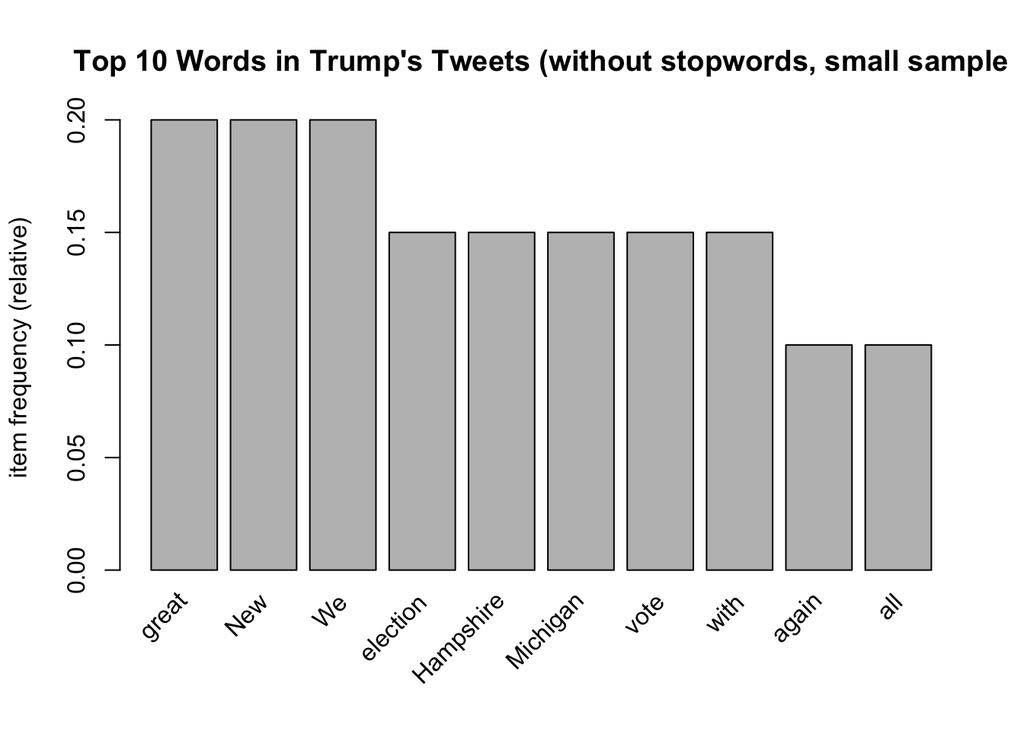

```r
itemFrequencyPlot(Tweets_1, topN = 10, type = "relative", main = "Top 10 Words in Trump's Tweets (without stopwords, small sample")
```

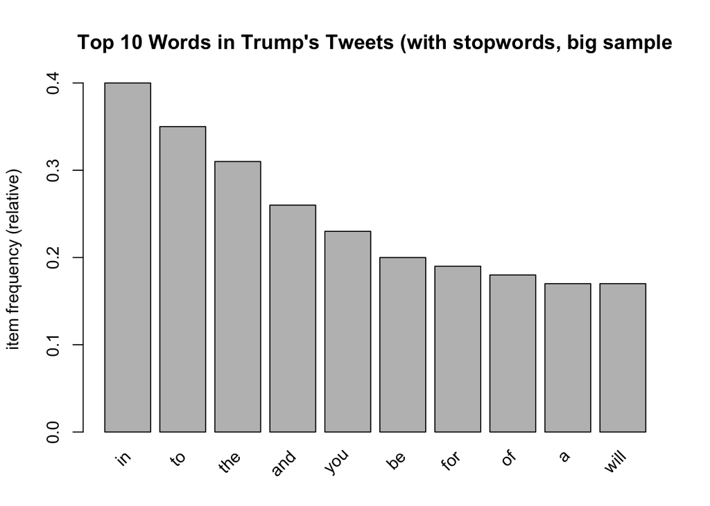

```r
itemFrequencyPlot(Tweets_2, topN = 10, type = "relative", main = "Top 10 Words in Trump's Tweets (with stopwords, big sample")
```

As it was mentioned previously, the stopwords are important, when one is dealing with NLP, however here - in association rules - we encounter a trade off between the possibility of creating any rules and creating the rules which are insightful. Only with pre-prepared small, homogeneous sample of Tweets, we are able to come up with rules and reasoning about the tweet’s components.

After all, there is a lot of “Hillary”, and “Thank” in the Tweets, as well as verbs using to make people feel united like “We” and “our”. This is also an important step, whether we would like to remove every stopword, or leave some of them in order to keep the broader message.

Now we might want to see lift heatmaps, which would indicate, the words that are together the most of the time and other vizualizations. Firstly, we want to create a bigger set of rules, by lowering the confidence rate.

```r
frequencyRules = ruleInduction(frequencyTweets_2, Tweets_2, confidence = .05)
inspect(frequencyRules)
```

```
##      lhs          rhs       support confidence lift      itemset
## [1]  {Join}    => {in}      0.10    1.0000000  2.5000000  1
## [2]  {in}      => {Join}    0.10    0.2500000  2.5000000  1
## [3]  {me}      => {in}      0.12    0.8571429  2.1428571  2
## [4]  {in}      => {me}      0.12    0.3000000  2.1428571  2
## [5]  {you}     => {Thank}   0.13    0.5652174  4.3478261  3
## [6]  {Thank}   => {you}     0.13    1.0000000  4.3478261  3
## [7]  {to}      => {Hillary} 0.10    0.2857143  1.9047619  4
## [8]  {Hillary} => {to}      0.10    0.6666667  1.9047619  4
## [9]  {the}     => {of}      0.11    0.3548387  1.9713262  5
## [10] {of}      => {the}     0.11    0.6111111  1.9713262  5
## [11] {of}      => {and}     0.11    0.6111111  2.3504274  6
## [12] {and}     => {of}      0.11    0.4230769  2.3504274  6
## [13] {you}     => {to}      0.12    0.5217391  1.4906832  7
## [14] {to}      => {you}     0.12    0.3428571  1.4906832  7
## [15] {to}      => {and}     0.11    0.3142857  1.2087912  8
## [16] {and}     => {to}      0.11    0.4230769  1.2087912  8
## [17] {the}     => {and}     0.12    0.3870968  1.4888337  9
## [18] {and}     => {the}     0.12    0.4615385  1.4888337  9
## [19] {to}      => {the}     0.12    0.3428571  1.1059908 10
## [20] {the}     => {to}      0.12    0.3870968  1.1059908 10
## [21] {the}     => {in}      0.12    0.3870968  0.9677419 11
## [22] {in}      => {the}     0.12    0.3000000  0.9677419 11
## [23] {to}      => {in}      0.11    0.3142857  0.7857143 12
## [24] {in}      => {to}      0.11    0.2750000  0.7857143 12
```

```
## Itemsets in Antecedent (LHS)
##  [1] "{Thank}"   "{you}"     "{Join}"    "{of}"      "{me}"
##  [6] "{Hillary}" "{and}"     "{in}"      "{the}"     "{to}"
## Itemsets in Consequent (RHS)
##  [1] "{to}"      "{the}"     "{in}"      "{and}"     "{Hillary}"
##  [6] "{me}"      "{of}"      "{Join}"    "{you}"     "{Thank}"
```

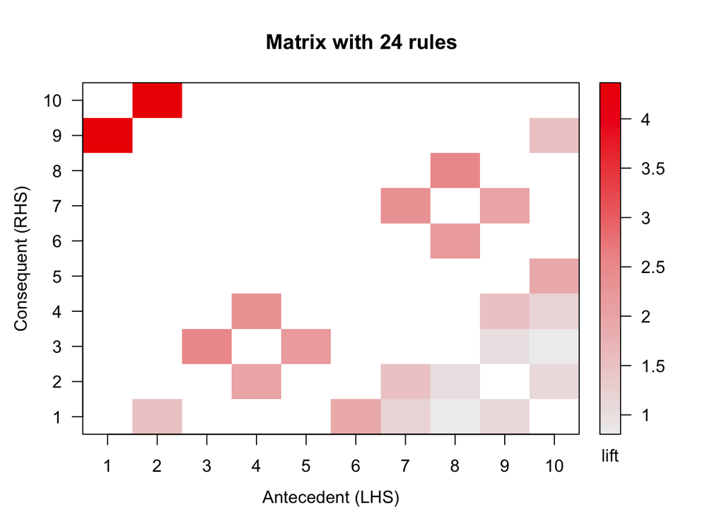

```r
plot(frequencyRules, method = "matrix", measure = "lift")
```

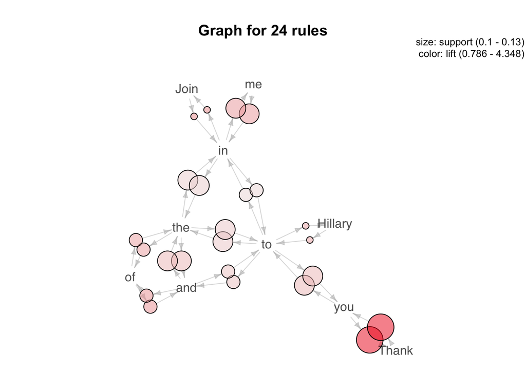

```r
plot(frequencyRules, method = "graph")
```

Unfortunately with the smaller sample without stopwords, lowering the confidence did not correspond with more rules, as the confidence of the group of words is really low among the subset.

As we can see, there are endless posibilities of researching this and many more dataset further using ARM. It can be perceived as an introduction to Natural Language Processing, where you can load thousands of texts, and see, which words often correspond with each other. The science of learning about sets can be really intricate but also rewarding!